# Financial Time Series Analysis Using ARIMA

Juan Felipe Quintero

2024-03-11

# Introduction

This document showcases an ARIMA analysis on financial time series data. The purpose is to demonstrate the application of ARIMA modeling to understand financial data trends, essential for predictive analysis in finance.

## Objective

To apply ARIMA modeling techniques to a financial time series dataset, providing insights into data trends and future predictions.

# Setup

Loading necessary libraries for the analysis.

```r
library(forecast)
library(TSA)
library(car)
library(urca)
library("tseries")
```

# Time Series Plot

Visualizing the data to get an initial understanding.

```r
setwd("C:/Users/pipeq/OneDrive - 04mar/Finanzas/Series de Tiempo/Datos series de tiempo")
z <- ts(scan("serie_ejemp.txt"))
```

# Analisis de estabilidad de la varianza:

Es necesario usar la transformacion Box-Cox?

# Analisis grafico

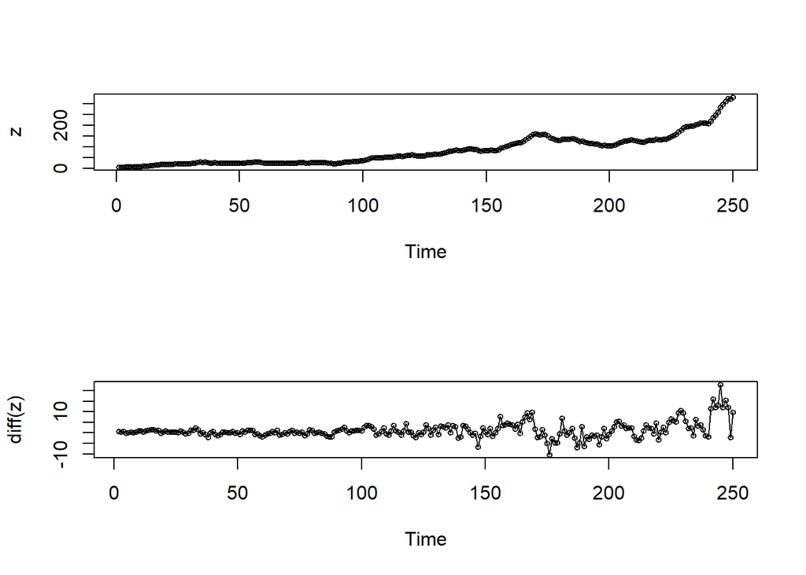

```r
par(mfrow=c(2,1))
plot.ts(z, type="o", cex=0.6)
plot.ts(diff(z), type="o", cex=0.6)
```

usando la libreria forecast

```r
BoxCox.lambda(z, method = c("loglik"), lower = -2, upper = 2)
```

```
## [1] 0.2
```

usando la librer?a car: supone que los datos son independientes

```r
tBoxCox=powerTransform(z)
summary(tBoxCox)
```

```
## bcPower Transformation to Normality
##   Est Power Rounded Pwr Wald Lwr Bnd Wald Upr Bnd
## z    0.1688        0.17       0.0353       0.3023
##
## Likelihood ratio test that transformation parameter is equal to 0
##  (log transformation)
##                            LRT df    pval
## LR test, lambda = (0) 6.316725  1 0.01196
##
## Likelihood ratio test that no transformation is needed
##                            LRT df       pval
## LR test, lambda = (1) 132.3367  1 < 2.22e-16
```

```r
(p=round(length(z)^(1/3)))
```

```
## [1] 6
```

```r
mod=arima(z, c(p, 1, 0))
lambda_opt <- BoxCox.lambda(z, method = "loglik", lower = -2, upper = 2)
z_transformed <- forecast::BoxCox(z, lambda = lambda_opt)
```

transformaci?n usando ra?z cuarta, lambda=0.25

```r
tz=z^.25
```

grafica de la serie original y transformada con lambda=.25

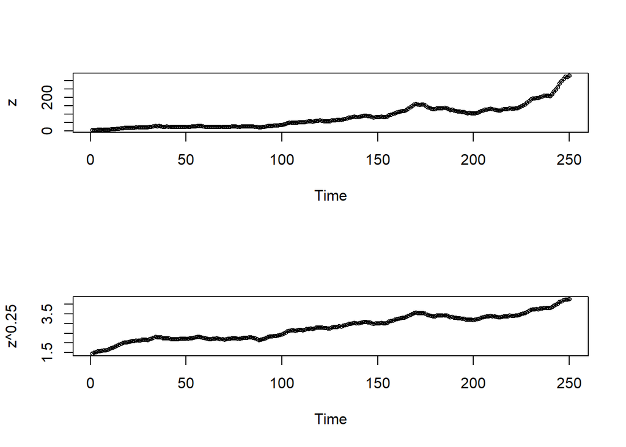

```r
par(mfrow=c(2,1))
plot.ts(z, type="o", cex=0.6)
plot.ts(z^.25, type="o", cex=0.6)
```

grafica de la serie diferenciada original y transformada

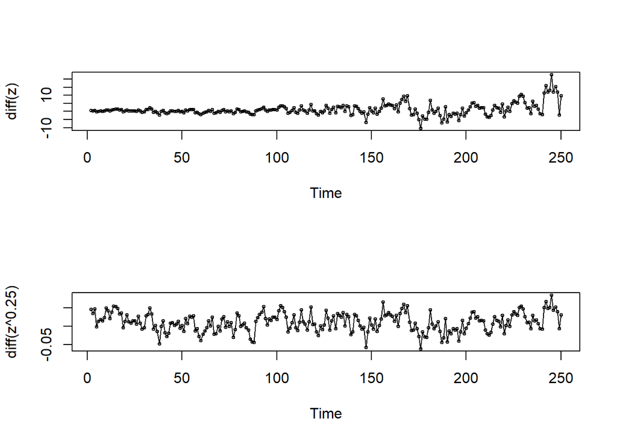

```r
par(mfrow=c(2,1))
plot.ts(diff(z), type="o", cex=.5)
plot.ts(diff(z^.25), type="o", cex=.5)
```

sigue el proceso de identificación usando z^.25 determinaci?n del valor de d grafica de la serie transformada

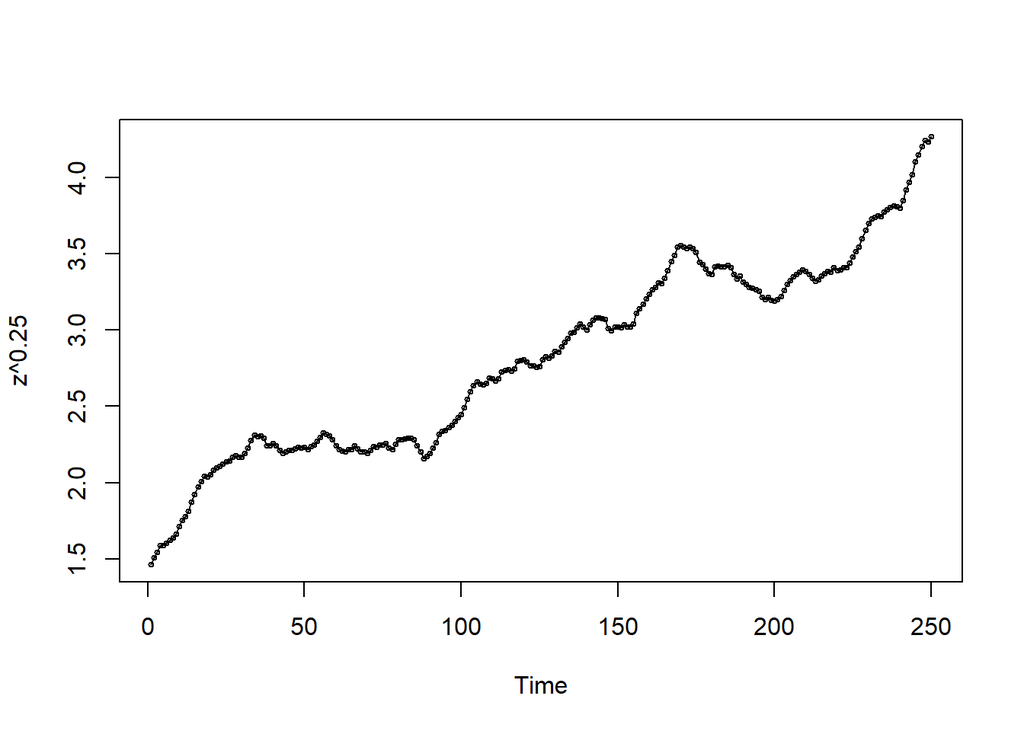

```r
plot.ts(z^.25, type="o", cex=.5)
```

correlogramas muestrales de la serie transformada

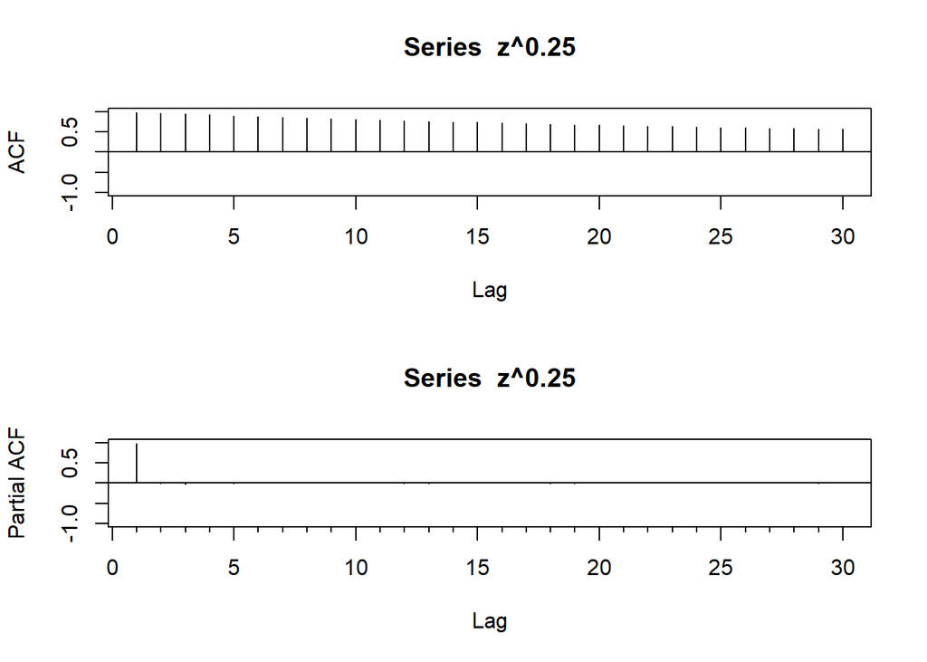

```r
par(mfrow=c(2,1))
Acf(z^.25, lag.max=30, ci=0,ylim=c(-1,1))
Pacf(z^.25, lag.max=30, ci=0, ylim=c(-1,1))
```

La serie es no estacionaria: Qu? tipo de serie es TS o DS? prueba de raices unitarias usando la libreria urca

```r
(maxlag=floor(12*(length(z)/100)^(1/4)))  # aproxima al entero menor o igual.
```

```
## [1] 15
```

```r
ru_tz=ur.df(z^.25, type = c("trend"), lags=maxlag, selectlags = c("BIC"))
summary(ru_tz)
```

```
##
## ###############################################
## # Augmented Dickey-Fuller Test Unit Root Test #
## ###############################################
##
## Test regression trend
##
##
## Call:
## lm(formula = z.diff ~ z.lag.1 + 1 + tt + z.diff.lag)
##
## Residuals:
##       Min        1Q    Median        3Q       Max
## -0.060812 -0.014146  0.001165  0.013544  0.052521
##
## Coefficients:
##               Estimate Std. Error t value Pr(>|t|)
## (Intercept)  2.282e-02  1.590e-02   1.435   0.1526
## z.lag.1     -1.233e-02  8.748e-03  -1.410   0.1600
## tt           1.282e-04  7.445e-05   1.722   0.0864 .
## z.diff.lag   5.572e-01  5.538e-02  10.062   <2e-16 ***
## ---
## Signif. codes:  0 '***' 0.001 '**' 0.01 '*' 0.05 '.' 0.1 ' ' 1
##
## Residual standard error: 0.02089 on 230 degrees of freedom
## Multiple R-squared:  0.3193, Adjusted R-squared:  0.3104
## F-statistic: 35.96 on 3 and 230 DF,  p-value: < 2.2e-16
##
##
## Value of test-statistic is: -1.4095 4.1783 1.8897
##
## Critical values for test statistics:
##       1pct  5pct 10pct
## tau3 -3.99 -3.43 -3.13
## phi2  6.22  4.75  4.07
## phi3  8.43  6.49  5.47
```

```r
ru_tz=ur.df(tz, type = c("trend"), lags=maxlag, selectlags = c("AIC"))
summary(ru_tz)
```

```
##
## ###############################################
## # Augmented Dickey-Fuller Test Unit Root Test #
## ###############################################
##
## Test regression trend
##
##
## Call:
## lm(formula = z.diff ~ z.lag.1 + 1 + tt + z.diff.lag)
##
## Residuals:
##       Min        1Q    Median        3Q       Max
## -0.060812 -0.014146  0.001165  0.013544  0.052521
##
## Coefficients:
##               Estimate Std. Error t value Pr(>|t|)
## (Intercept)  2.282e-02  1.590e-02   1.435   0.1526
## z.lag.1     -1.233e-02  8.748e-03  -1.410   0.1600
## tt           1.282e-04  7.445e-05   1.722   0.0864 .
## z.diff.lag   5.572e-01  5.538e-02  10.062   <2e-16 ***
## ---
## Signif. codes:  0 '***' 0.001 '**' 0.01 '*' 0.05 '.' 0.1 ' ' 1
##
## Residual standard error: 0.02089 on 230 degrees of freedom
## Multiple R-squared:  0.3193, Adjusted R-squared:  0.3104
## F-statistic: 35.96 on 3 and 230 DF,  p-value: < 2.2e-16
##
##
## Value of test-statistic is: -1.4095 4.1783 1.8897
##
## Critical values for test statistics:
##       1pct  5pct 10pct
## tau3 -3.99 -3.43 -3.13
## phi2  6.22  4.75  4.07
## phi3  8.43  6.49  5.47
```

validacion de la ecuacion ADF

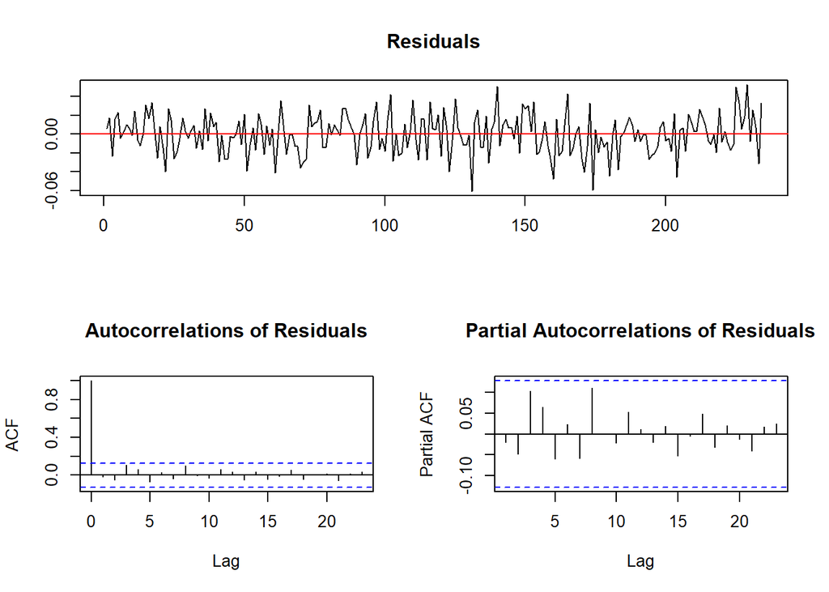

```r
    resid=ru_tz@testreg$residuals             # residuales del modelo ADF
    plot(ru_tz)                               # diagnosticos
```

```r
    auto.arima(resid, max.p=5, max.q=5)       # busqueda "autom?tica"
```

```
## Series: resid
## ARIMA(0,0,0) with zero mean
##
## sigma^2 = 0.0004291:  log likelihood = 575.17
## AIC=-1148.35   AICc=-1148.33   BIC=-1144.89
```

```r
    cheq=Arima(resid, c(0,0,0), include.constant=TRUE)
    summary(cheq)
```

```
## Series: resid
## ARIMA(0,0,0) with non-zero mean
##
## Coefficients:
##         mean
##       0.0000
## s.e.  0.0014
##
## sigma^2 = 0.0004309:  log likelihood = 575.17
## AIC=-1146.35   AICc=-1146.3   BIC=-1139.44
##
## Training set error measures:
##                         ME      RMSE        MAE MPE MAPE      MASE        ACF1
## Training set -2.338535e-19 0.0207139 0.01656634 100  100 0.7025088 -0.01972385
```

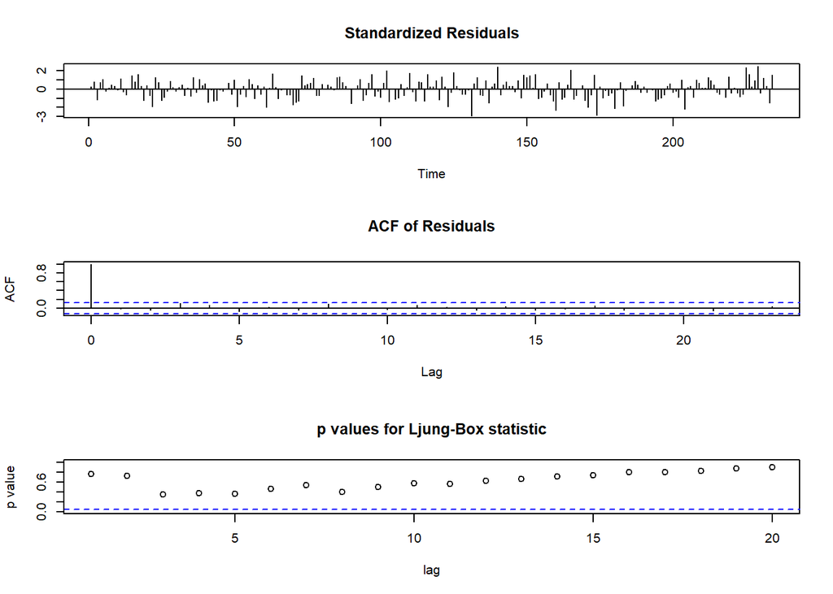

```r
    tsdiag(cheq, gof=20)
```

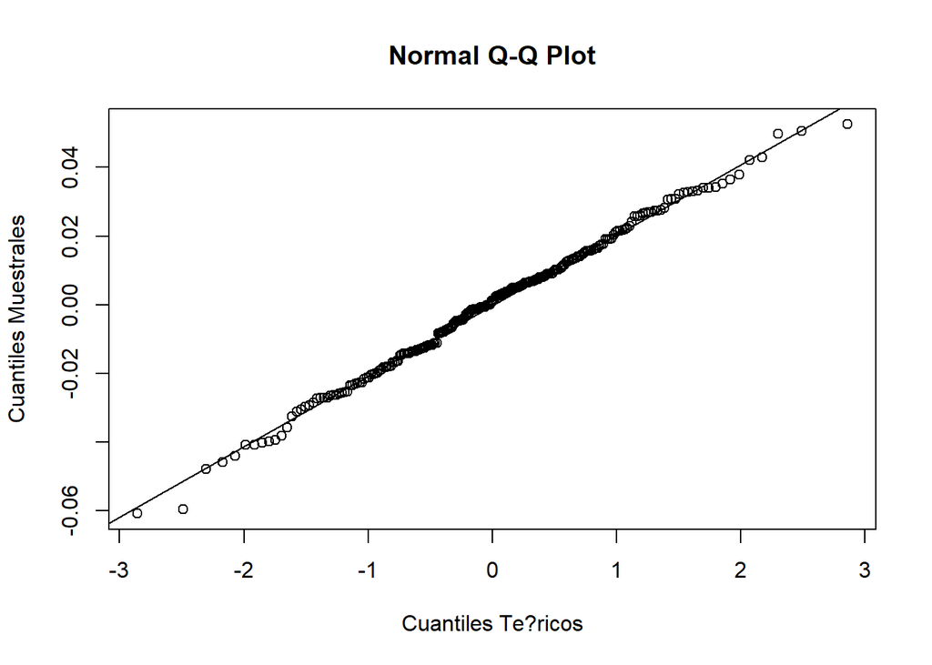

```r
  # Verificacion de normalidad en los residuales
    qqnorm(resid,  xlab = "Cuantiles Te?ricos", ylab = "Cuantiles Muestrales")
    qqline(resid)
```

```r
    shapiro.test(resid)                # prueba de Shapiro-Wilks
```

```
##
##  Shapiro-Wilk normality test
##
## data:  resid
## W = 0.9958, p-value = 0.7789
```

```r
    library(fBasics)                   # librer?a fBasics contiene la prueba Jarque-Bera
    jarqueberaTest(resid )             # prueba Jarque-Bera
```

```
##
## Title:
##  Jarque - Bera Normalality Test
##
## Test Results:
##   STATISTIC:
##     X-squared: 0.6827
##   P VALUE:
##     Asymptotic p Value: 0.7108
```

el modelo ADF satisface los supuestos b?sicos Conclusi?n: La serie tz contiene al menos una raiz unitaria.

Examen de m?s ra?ces unitarias grafica de la serie diferenciada una vez

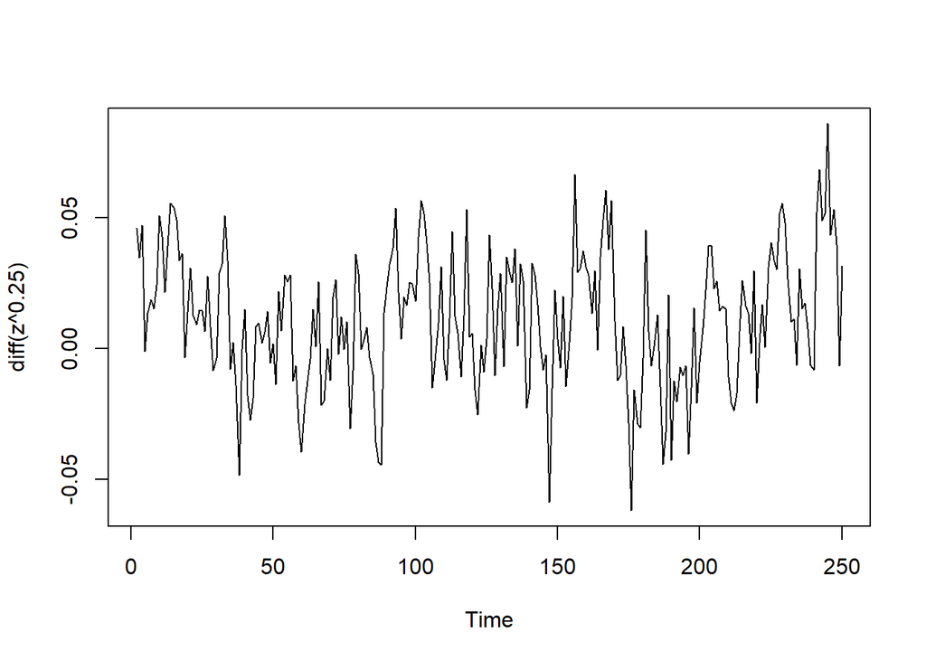

```r
plot.ts(diff(z^.25), type="l")
```

prueba de si hay ra?z unitarias en z^.25 diferenciada una vez.

```r
ru_dif_tz=ur.df(diff(z^.25), type = c("drift"), lags=maxlag, selectlags = c("BIC"))
summary(ru_dif_tz)
```

```
##
## ###############################################
## # Augmented Dickey-Fuller Test Unit Root Test #
## ###############################################
##
## Test regression drift
##
##
## Call:
## lm(formula = z.diff ~ z.lag.1 + 1 + z.diff.lag)
##
## Residuals:
##       Min        1Q    Median        3Q       Max
## -0.061298 -0.013680  0.001234  0.013816  0.052664
##
## Coefficients:
##              Estimate Std. Error t value Pr(>|t|)
## (Intercept)  0.004256   0.001509   2.821  0.00521 **
## z.lag.1     -0.439554   0.062080  -7.080 1.73e-11 ***
## z.diff.lag  -0.018098   0.065955  -0.274  0.78402
## ---
## Signif. codes:  0 '***' 0.001 '**' 0.01 '*' 0.05 '.' 0.1 ' ' 1
##
## Residual standard error: 0.02106 on 230 degrees of freedom
## Multiple R-squared:  0.2242, Adjusted R-squared:  0.2174
## F-statistic: 33.23 on 2 and 230 DF,  p-value: 2.109e-13
##
##
## Value of test-statistic is: -7.0804 25.0675
##
## Critical values for test statistics:
##       1pct  5pct 10pct
## tau2 -3.46 -2.88 -2.57
## phi1  6.52  4.63  3.81
```

reespecificaci?n del modelo con lags=0

```r
ru_dif_tz=ur.df(diff(z^.25), type = c("drift"), lags=0)
summary(ru_dif_tz)   # valide la ecuaci?n usada para la prueba
```

```
##
## ###############################################
## # Augmented Dickey-Fuller Test Unit Root Test #
## ###############################################
##
## Test regression drift
##
##
## Call:
## lm(formula = z.diff ~ z.lag.1 + 1)
##
## Residuals:
##       Min        1Q    Median        3Q       Max
## -0.061872 -0.013904  0.001424  0.013591  0.051904
##
## Coefficients:
##              Estimate Std. Error t value Pr(>|t|)
## (Intercept)  0.004751   0.001447   3.283  0.00118 **
## z.lag.1     -0.429965   0.052190  -8.239 1.04e-14 ***
## ---
## Signif. codes:  0 '***' 0.001 '**' 0.01 '*' 0.05 '.' 0.1 ' ' 1
##
## Residual standard error: 0.02085 on 246 degrees of freedom
## Multiple R-squared:  0.2162, Adjusted R-squared:  0.2131
## F-statistic: 67.87 on 1 and 246 DF,  p-value: 1.039e-14
##
##
## Value of test-statistic is: -8.2385 33.9374
##
## Critical values for test statistics:
##       1pct  5pct 10pct
## tau2 -3.46 -2.88 -2.57
## phi1  6.52  4.63  3.81
```

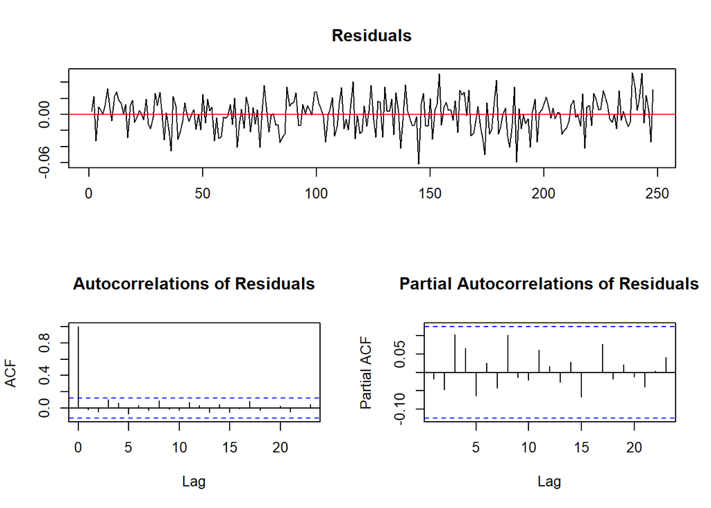

```r
  # validaci?n de la ecuaci?n ADF
    residn=ru_dif_tz@testreg$residuals             # residuales del modelo ADF
    plot(ru_dif_tz)                                # diagn?sticos
```

```r
    auto.arima(resid, max.p=5, max.q=5)       # busqueda "autom?tica"
```

```
## Series: resid
## ARIMA(0,0,0) with zero mean
##
## sigma^2 = 0.0004291:  log likelihood = 575.17
## AIC=-1148.35   AICc=-1148.33   BIC=-1144.89
```

```r
    cheqn=Arima(residn, c(0,0,0), include.constant=TRUE)
    summary(cheqn)
```

```
## Series: residn
## ARIMA(0,0,0) with non-zero mean
##
## Coefficients:
##         mean
##       0.0000
## s.e.  0.0013
##
## sigma^2 = 0.0004331:  log likelihood = 608.94
## AIC=-1213.88   AICc=-1213.83   BIC=-1206.85
##
## Training set error measures:
##                        ME       RMSE        MAE MPE MAPE     MASE        ACF1
## Training set 5.873985e-16 0.02076794 0.01663334 100  100 0.704795 -0.01720576
```

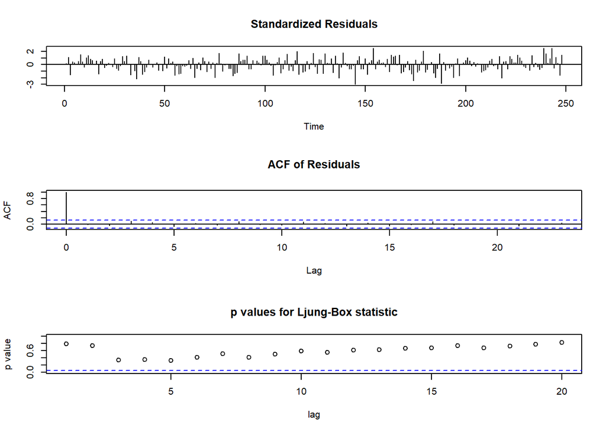

```r
    tsdiag(cheqn, gof=20)
```

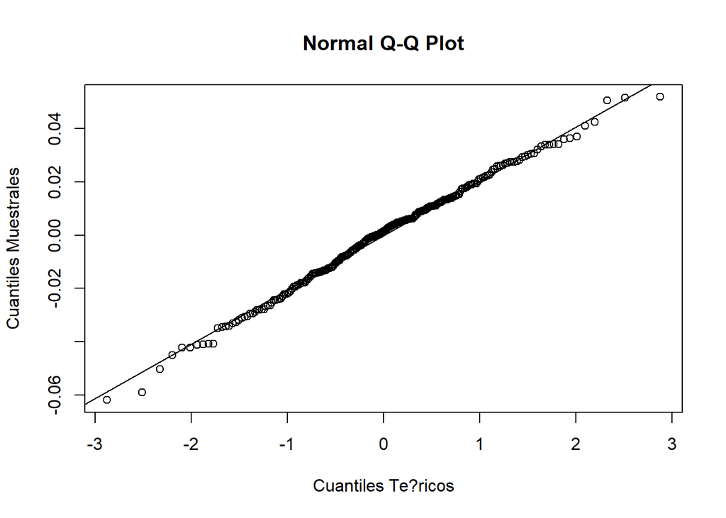

```r
  # Verificacion de normalidad en los residuales
    qqnorm(residn,  xlab = "Cuantiles Te?ricos", ylab = "Cuantiles Muestrales")
    qqline(residn)
```

```r
    shapiro.test(residn)                # prueba de Shapiro-Wilks
```

```
##
##  Shapiro-Wilk normality test
##
## data:  residn
## W = 0.9953, p-value = 0.6502
```

```r
    library(fBasics)                   # librer?a fBasics contiene la prueba Jarque-Bera
    jarqueberaTest(residn)             # prueba Jarque-Bera
```

```
##
## Title:
##  Jarque - Bera Normalality Test
##
## Test Results:
##   STATISTIC:
##     X-squared: 1.4489
##   P VALUE:
##     Asymptotic p Value: 0.4846
```

Conclusi?n: La serie z^.25 diferenciada no contiene ra?z unitaria.Por tanto, la serie z^.25 pertenece a la clase de modelos ARIMA con d=1 y deriva.

determinaci?n de los valores de (p, q) de modelo ARMA para (1-B)z^.25 selecci?n del modelo usando los correlogramas muestrales correlogramas muestrales para (1-B)z^.25 diferenciada una vez

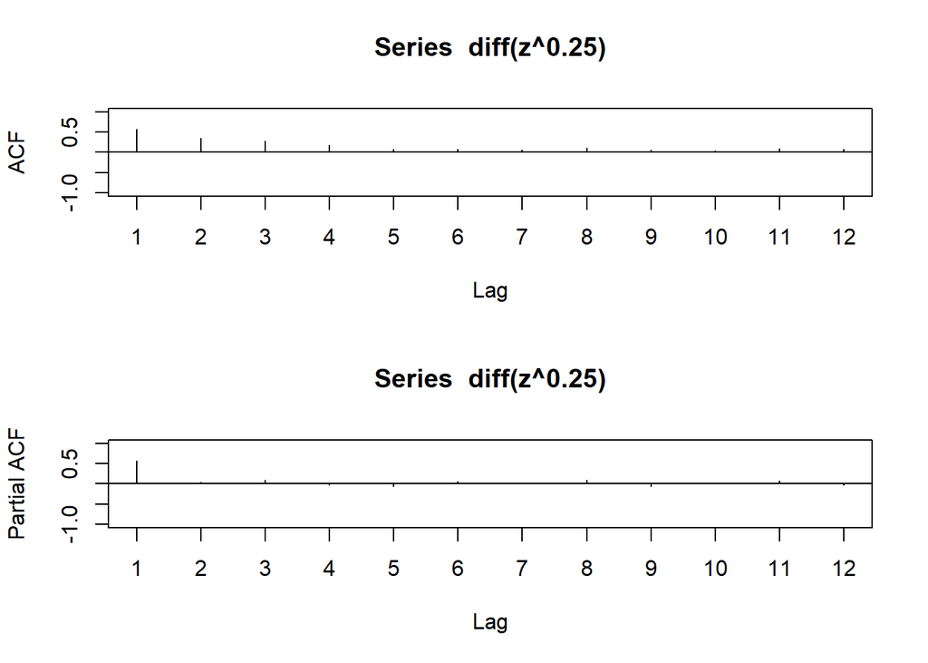

```r
par(mfrow=c(2,1))
Acf(diff(z^.25), lag.max=12, ci=0, ylim=c(-1,1))
Pacf(diff(z^.25), lag.max=12, ci=0, ylim=c(-1,1))
```

Parece indicar un AR(1) en diferencias. correlogramas muestrales para (1-B)z^.25 con PACF con bandas

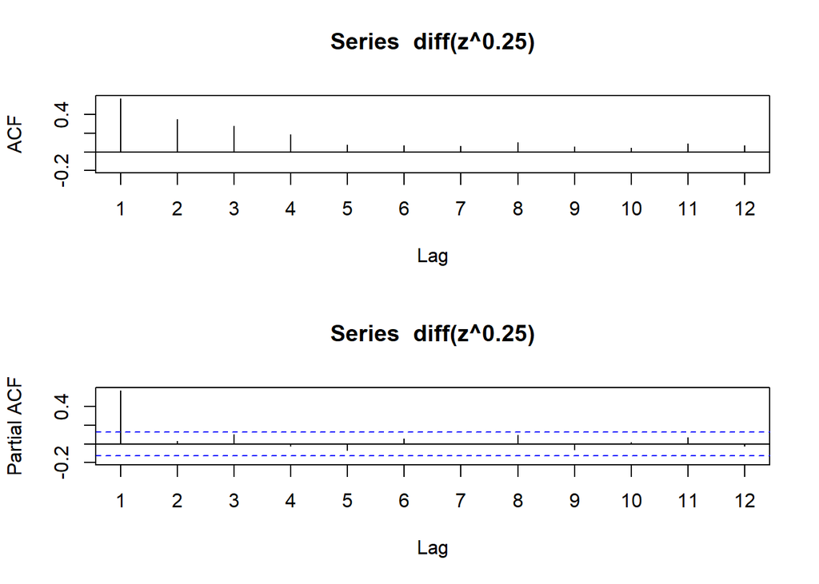

```r
par(mfrow=c(2,1))
Acf(diff(z^.25), lag.max=12, ci=0)
Pacf(diff(z^.25), lag.max=12)
```

La serie parece ser generada por un ARIMA(1,1,0) con deriva

selecci?n del modelo usando la EACF

```r
eacf(diff(z^.25))
```

```
## AR/MA
##   0 1 2 3 4 5 6 7 8 9 10 11 12 13
## 0 x x x x o o o o o o o  o  o  o
## 1 o x o o x o o o o o o  o  o  o
## 2 x x o o x o o o o o o  o  o  o
## 3 x x o o o o o o o o o  o  o  o
## 4 x x o o x o o o o o o  o  o  o
## 5 x x o o x o o o o o o  o  o  o
## 6 o x x o x o o o o o o  o  o  o
## 7 o x x o x o x o o o o  o  o  o
```

hay evidencia sobre el modelo ARIMA(1,1,0).

selecci?n “autom?tica” del modelo

```r
auto.arima(z^.25, max.p=5, max.q=5, ic=c("aic"))
```

```
## Series: z^0.25
## ARIMA(1,1,0) with drift
##
## Coefficients:
##          ar1   drift
##       0.5722  0.0116
## s.e.  0.0520  0.0031
##
## sigma^2 = 0.0004364:  log likelihood = 610.76
## AIC=-1215.51   AICc=-1215.41   BIC=-1204.96
```

```r
auto.arima(z^.25, d=1, max.p=5, max.q=5, ic=c("bic"))
```

```
## Series: z^0.25
## ARIMA(1,1,0) with drift
##
## Coefficients:
##          ar1   drift
##       0.5722  0.0116
## s.e.  0.0520  0.0031
##
## sigma^2 = 0.0004364:  log likelihood = 610.76
## AIC=-1215.51   AICc=-1215.41   BIC=-1204.96
```

# los resultados indican que tanto el AIC como el BIC se?alan un modelo ARIMA(1,1,0)

Conclusi?n: modelo seleccionado es: (1-phi1*B)(1-B)z^.25=constante+at, es decir, z^.25 sigue un modelo ARIMA(1,1,0) con deriva. la tendencia observada en la gr?fica de z^.25 es una mezcla de tendencia aleatoria y detemin?stica lineal

ETAPA DE ESTIMACI?N estimaci?n ML exacta con valores iniciales dados por la estimaci?n condicional

```r
mod1_CSS_ML=Arima(z, c(1, 1, 0), include.drift=TRUE, lambda=.25, method = c("CSS-ML"),
                  biasadj=TRUE)
summary(mod1_CSS_ML)
```

```
## Series: z
## ARIMA(1,1,0) with drift
## Box Cox transformation: lambda= 0.25
##
## Coefficients:
##          ar1   drift
##       0.5722  0.0463
## s.e.  0.0520  0.0123
##
## sigma^2 = 0.006982:  log likelihood = 265.57
## AIC=-525.14   AICc=-525.04   BIC=-514.58
##
## Training set error measures:
##                      ME     RMSE      MAE         MPE     MAPE      MASE
## Training set 0.01557317 2.768309 1.798955 -0.07923247 2.444165 0.7286349
##                    ACF1
## Training set -0.0309263
```

# ETAPA DE DIAGN?STICOS

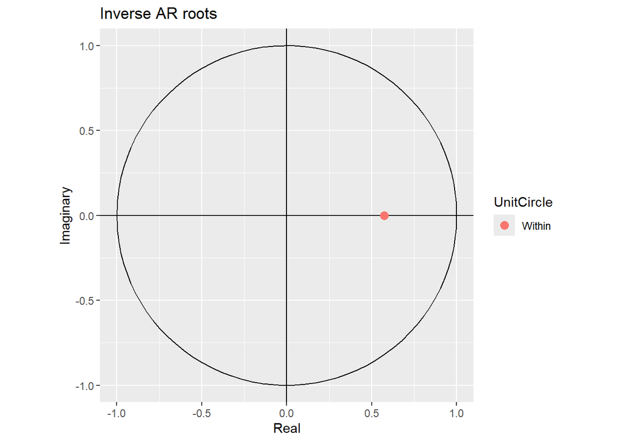

```r
library(ggplot2)
autoplot(mod1_CSS_ML)
```

# An?lisis de los residuales

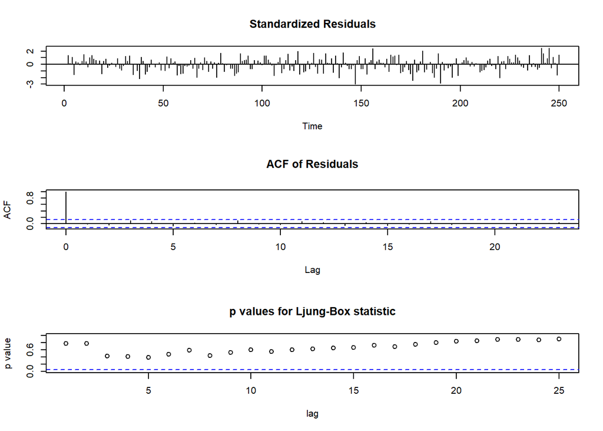

```r
tsdiag(mod1_CSS_ML, gof=25)            # de la librer?a stats
```

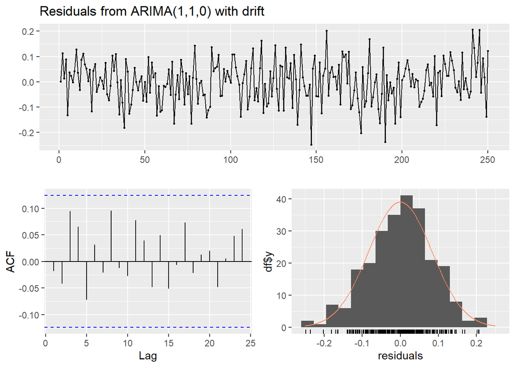

```
##
##  Ljung-Box test
##
## data:  Residuals from ARIMA(1,1,0) with drift
## Q* = 16.536, df = 24, p-value = 0.8678
##
## Model df: 1.   Total lags used: 25
```

```r
checkresiduals(mod1_CSS_ML, lag=25)
```

# de la librer?a forecast

los residuales parecen provenir de un proceso de ruido blanco de media cero.

chequeo de observaciones at?picas extremas (no es un an?lisis completo de outliers) obtenci?n de los residuales del modelo estimado

```r
(res1_CSS_ML=residuals(mod1_CSS_ML))
```

```
## Time Series:
## Start = 1
## End = 250
## Frequency = 1
##   [1]  0.0018043139  0.1132068064  0.0136036855  0.0889917906 -0.1319289110
##   [6]  0.0372594888  0.0240243076 -0.0018471965  0.0422302644  0.1274169634
##  [11]  0.0357578894 -0.0318379221  0.0877667785  0.1117228548  0.0690524894
##  [16]  0.0532724575  0.0023717665  0.0478949641 -0.1161750490  0.0432827809
##  [21]  0.0713451080 -0.0395741899 -0.0122580309  0.0182304118  0.0046121815
##  [26] -0.0266442793  0.0751233834 -0.0490565996 -0.0723352804 -0.0152937254
##  [31]  0.1037890695  0.0430673991  0.1092731520 -0.0015035644 -0.1283795307
##  [36]  0.0079952078 -0.0810003754 -0.1811057412  0.0900520830  0.0406687318
##  [41] -0.1252212773 -0.0889222762 -0.0322617539  0.0563538966 -0.0001797107
##  [46] -0.0338467619  0.0007712442  0.0222164253 -0.0738213302 -0.0002619654
##  [51] -0.0782646643  0.0983673033 -0.0422526763  0.0765381692  0.0175887536
```

[output cut: 39 more lines]

```r
res1_est=res1_CSS_ML/(mod1_CSS_ML$sigma2^.5)  # estandarizaci?n de los residuales
```

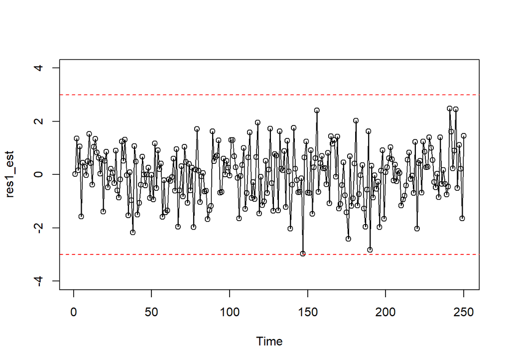

```r
plot.ts(res1_est, type="o", ylim=c(-4, 4))
abline(a=-3, b=0, col="red", lty=2)
abline(a=3, b=0, col="red", lty=2)
```

detecci?n de observaciones at?picas

```r
ind=(abs(res1_est)>3)
sum(ind)    # indica el n?mero de observaciones at?cas extremas
```

```
## [1] 0
```

```r
(grupo=cbind(res1_est, ind))  # lista con los residuales estandarizados y un indicador
```

```
## Time Series:
## Start = 1
## End = 250
## Frequency = 1
##         res1_est ind
##   1  0.021594104   0
##   2  1.354863806   0
##   3  0.162809479   0
##   4  1.065057481   0
##   5 -1.578930739   0
##   6  0.445923124   0
##   7  0.287523920   0
##   8 -0.022107325   0
##   9  0.505413575   0
##  10  1.524931560   0
```

[output cut: 240 more lines]

```r
                              # que es 1 si la observaci?n es at?pica
```

# chequeo de normalidad

gr?fico cuantil-cuantil

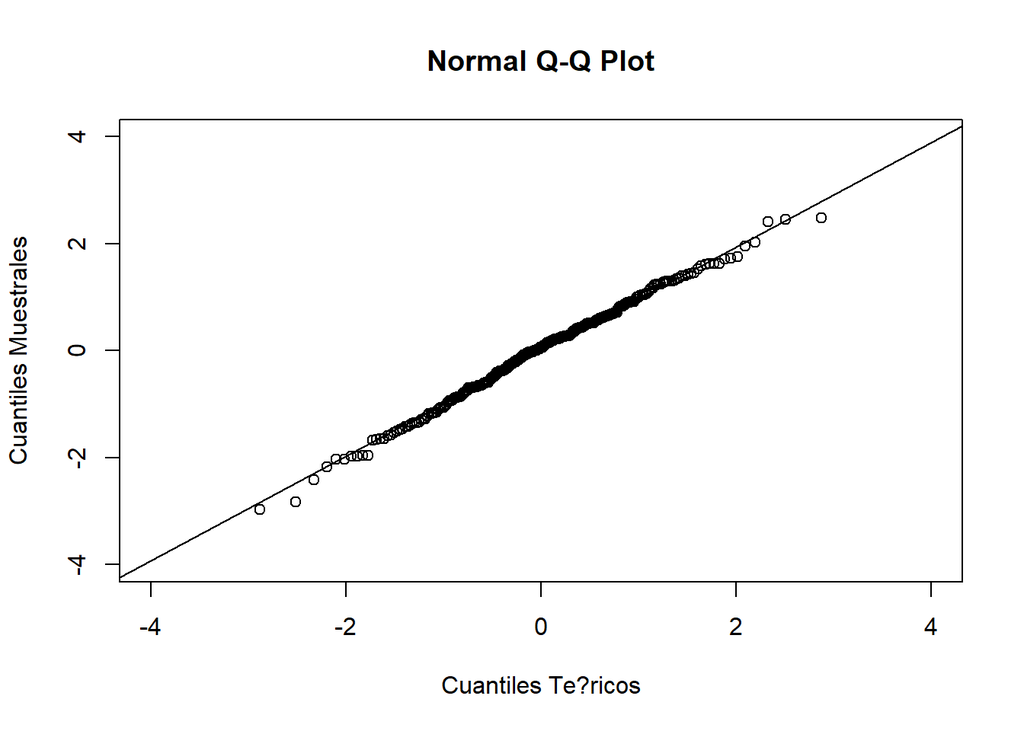

```r
qqnorm(res1_est,  xlab = "Cuantiles Te?ricos", ylab = "Cuantiles Muestrales",
       xlim=c(-4,4), ylim=c(-4,4))
qqline(res1_est)
```

conclusi?n: No se detecta alejamiento fuerte de la normalidad

gr?fico del histograma, densidad kernel y gr?fico normal

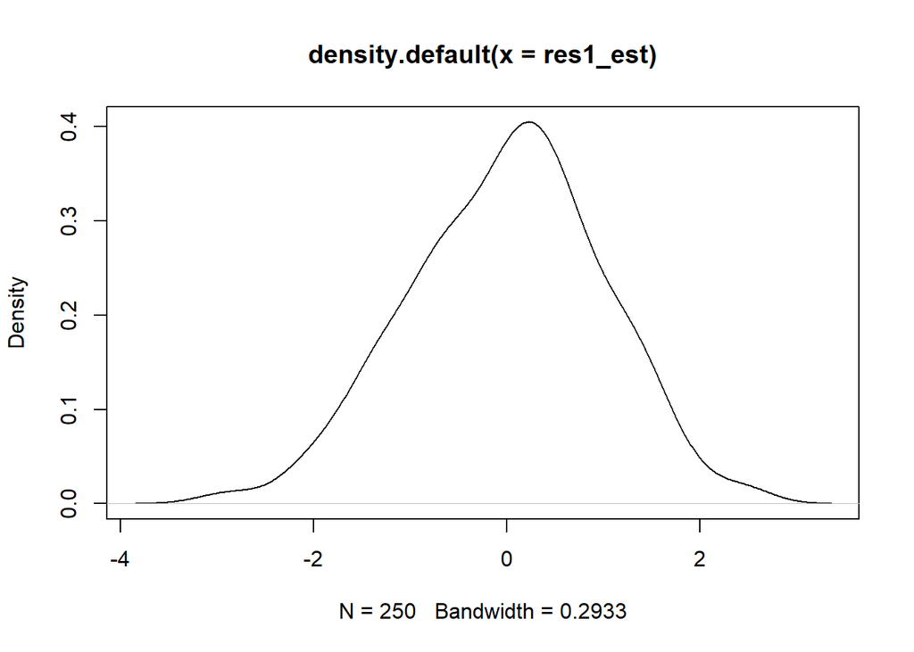

```r
plot(density(res1_est))
```

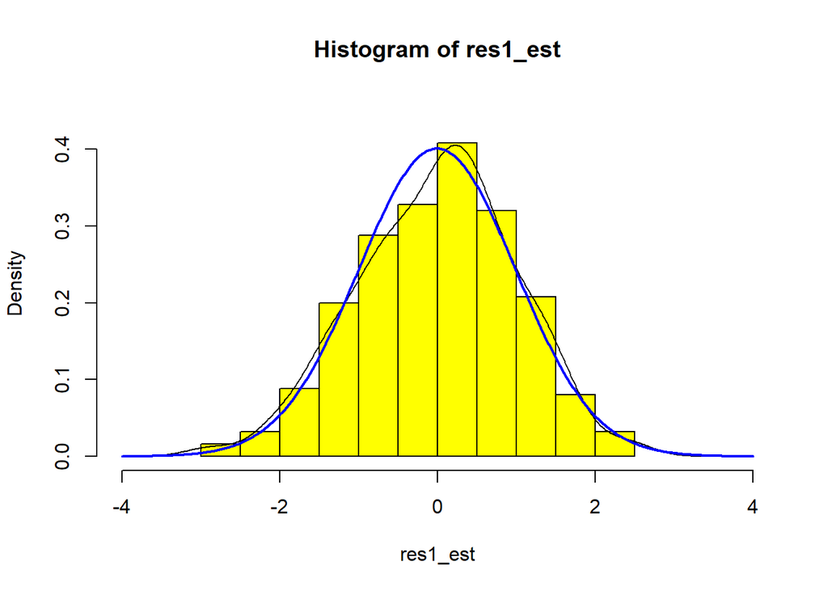

```r
mu<-mean(res1_est)
sigm<-sd(res1_est)
x<-seq(-4,4,length=500)
y<-dnorm(x,mu,sigm)
hist(res1_est,prob=T,ylim=c(0,.45),xlim=c(-4,4),col="yellow")
lines(density(res1_est))
lines(x,y,lwd=2,col="blue")
```

conclusi?n: No se detecta alejamiento fuerte de la normalidad

pruebas de normalidad

```r
shapiro.test(res1_est)                 #prueba de Shapiro-Wilks
```

```
##
##  Shapiro-Wilk normality test
##
## data:  res1_est
## W = 0.99517, p-value = 0.6216
```

```r
normalTest(res1_est, method=("jb"))  # librer?a fBasics: puede realizar otras pruebas
```

```
##
## Title:
##  Jarque - Bera Normalality Test
##
## Test Results:
##   STATISTIC:
##     X-squared: 1.5424
##   P VALUE:
##     Asymptotic p Value: 0.4625
```

```r
                                     # "ks" for the Kolmogorov-Smirnov one?sample test,
                                     # "sw" for the Shapiro-Wilk test,
                                     # "jb" for the Jarque-Bera Test,
                                     # "da" for the D'Agostino Test. The default value is "ks"
```

# conclusi?n: No se rechaza la normalidad.

# valores ajustados del modelo para z transformada

```r
(ajust=mod1_CSS_ML$fitted)
```

```
## Time Series:
## Start = 1
## End = 250
## Frequency = 1
##   [1]   4.576666   4.808966   5.631057   6.054859   6.934435   6.457322
##   [7]   6.822143   7.195582   7.430148   7.972755   9.296182  10.141462
##  [13]  10.354456  11.540740  13.243284  14.777960  16.225345  17.041413
##  [19]  18.338469  17.432639  18.254583  19.721790  19.806941  20.074518
##  [25]  20.763018  21.329195  21.411051  23.025800  22.920893  22.180267
##  [31]  22.141223  24.139763  25.661426  28.571435  29.765129  28.182632
##  [37]  28.591997  27.458473  24.340362  25.561921  26.656963  24.984187
##  [43]  23.542161  22.954160  23.967315  24.421690  24.317682  24.702544
##  [49]  25.535717  24.788913  25.051845  24.063478  25.940462  25.862093
##  [55]  27.750888  28.922559  30.431287  28.638476  28.484427  26.519379
##  [61]  24.452525  23.973858  23.665036  23.693266  24.829868  24.501815
```

[output cut: 31 more lines]

gr?fico para los valores ajustados y los valores observados

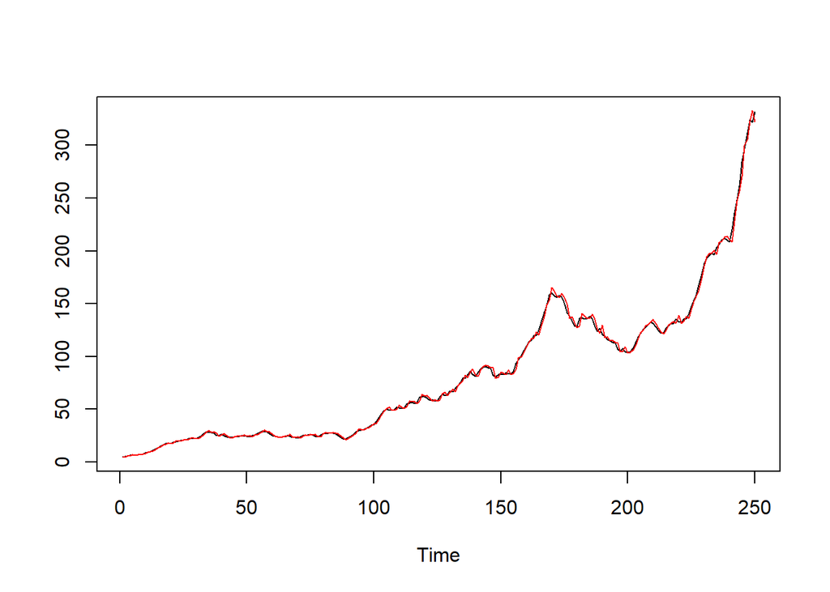

```r
ts.plot(z,ajust)   # gr?fico de las series contra el tiempo
lines(z, col="black")
lines(ajust, col="red")
```

diagrama de dispersi?n gr?fico de dispersi?n de la serie observada contra la serie ajustada

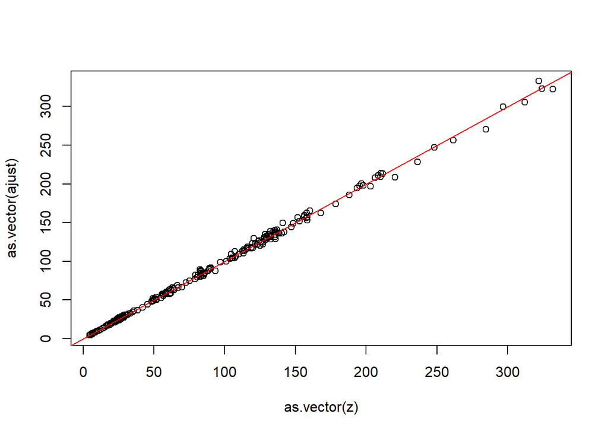

```r
plot(as.vector(z),as.vector(ajust), type="p")
abline(0,1, col="red")
```

El modelo ARIMA(1,1,0) con deriva parece ser adecuado.